# Final Project Executive Summary

Data Science III (STAT 301-3)

Jordi Parry, Albert Kim, & Zach Kornbluth

6/8/2021

### Data

For this project, we chose to use a dataset of Major League Baseball batting statistics. This data has many advanced statistics for individual batters with at least 100 plate appearances in one season from the 2019-20 seasons. Using these many advanced statistics, we chose to model the data treating OPS (On-base plus slugging percentage) as the outcome variable. OPS is perhaps the most prominent statistic used in baseball as an all-encompassing representation of a batter’s success. By creating, tuning, and fitting models we hope to be able to accurately predict a player’s OPS given his performance in various batted ball and plate discipline statistics.

```r
# loading packages and data
library(tidyverse)
library(tidymodels)
library(readr)
library(ggplot2)
library(psych)
library(skimr)
library(gt)

# set seed for reproducible results
set.seed(9876)

# read in training data
training_data_mlb <- read_csv('data/training_data_mlb.csv')
```

### Exploratory Data Analysis

To better understand the data for our modeling, we want to get a sense of the distribution of our outcome variable, OPS, and of the relationships between our predictor variables. The following graphs demonstrate the distribution of OPS and correlations between all predictors.

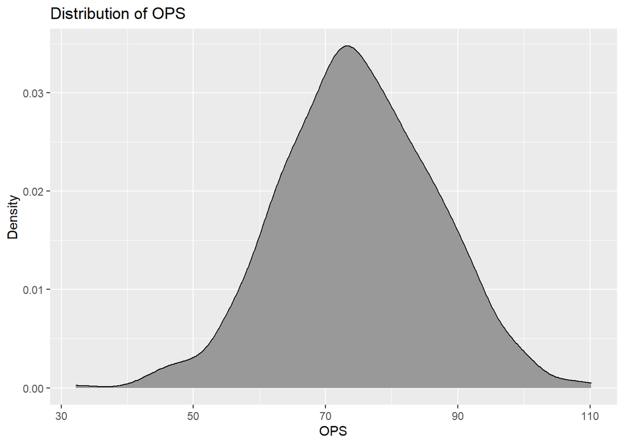

```r
# see distribution of the response variable
ggplot(training_data_mlb, aes(x = ops)) +
  geom_density(fill = "grey60") +
  labs(title = "Distribution of OPS",
       x = "OPS",
       y = "Density")
```

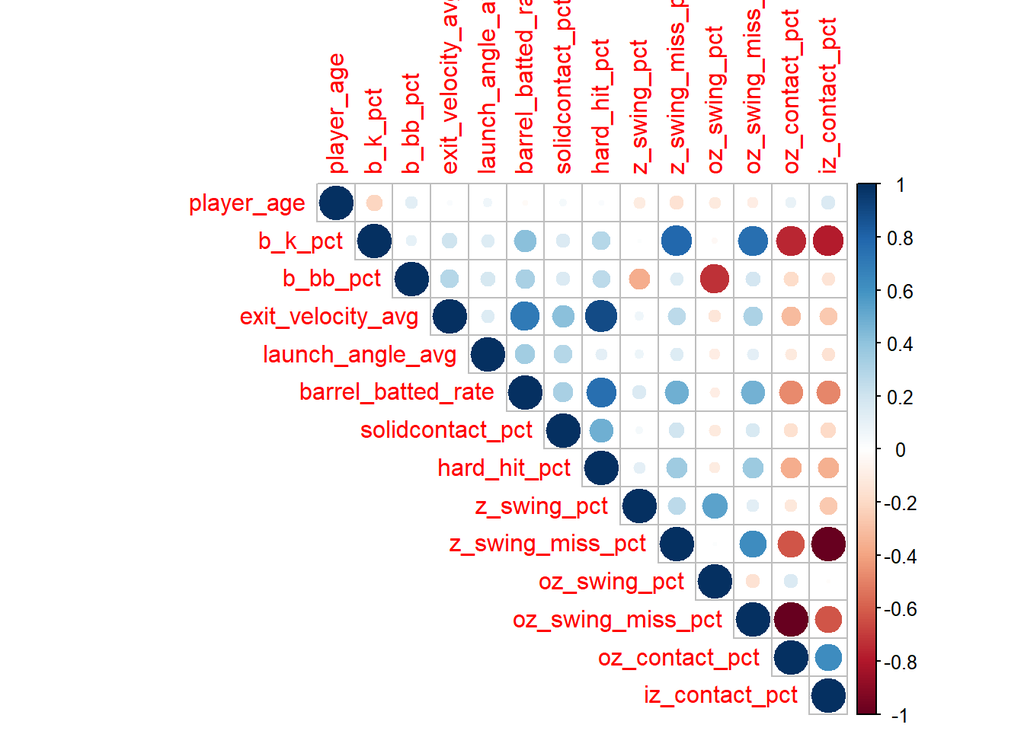

```r
# check correlations between predictors to see if removal is necessary for any
corrplot::corrplot(cor(training_data_mlb %>% select(-c(ops))), method = "circle", type = "upper")
```

From the first plot we can see that OPS is centered near 75 and that most players have OPS’ between 60 and 90. As such, the distribution is relatively symmetric, indicating that transformations of the outcome variable is unnecessary.

The second plot shows us that contact rate and swing-and-miss rate are so highly correlated. In order to avoid potential issues with collinearity, we chose to remove oz_swing_miss_pct and z_swing_miss_pct from the data set prior to training models.

### Fitting an Ensemble Model

After splitting and folding the data and feature engineering, we chose to tune Random Forest, Boosted Tree, Support Vector Machine, and Neural Net models, and to create an ensemble model of our RF, BT, and SVM models. The following table shows the weights of different models in the final ensemble model:

```r
# creating table of model weights
load(file = "tuning_scripts/mlb_model_stacked")
stacks:::top_coefs(mlb_model_stacked) %>%
gt() %>%
tab_header(title = "Weights for Member Models in Ensemble Model") %>%
fmt_number(columns = c(weight), decimals = 3)
```

Weights for Member Models in Ensemble Model

| member | type | weight |
| --- | --- | --- |
| rf_tuned_1_25 | rand_forest | 0.315 |
| svm_res_1_20 | svm_rbf | 0.269 |
| bt_tuned_1_119 | boost_tree | 0.181 |
| bt_tuned_1_112 | boost_tree | 0.107 |
| bt_tuned_1_124 | boost_tree | 0.102 |
| bt_tuned_1_122 | boost_tree | 0.087 |
| svm_res_1_15 | svm_rbf | 0.015 |

### Ensemble Model Results

```r
# load ensemble model blended file
load(file = "tuning_scripts/mlb_model_stacked_fitted")
test_mlb <- read_csv("data/testing_data_mlb.csv")
test_mlb <- test_mlb %>%
  bind_cols(predict(mlb_model_stacked_fitted, .))

# creating table of performance
member_preds <-
  test_mlb %>%
  select(ops) %>%
  bind_cols(predict(mlb_model_stacked_fitted, test_mlb)) %>%
  rmse(.pred, ops) %>%
  gt() %>%
  tab_header(title = "RMSE Score for the Ensemble Model") %>%
  fmt_number(columns = c(.estimate), decimals = 3)
member_preds
```

RMSE Score for the Ensemble Model

| .metric | .estimator | .estimate |
| --- | --- | --- |
| rmse | standard | 6.055 |

With an RMSE value of 6.055, the results suggest strong predictive power of our ensemble model. Therefore, we have demonstrated the efficacy of our modeling approaches on predicting OPS. To illustrate just how well it performed, below is a plot of the ensemble model’s predictions against the actual OPS’ in the test data:

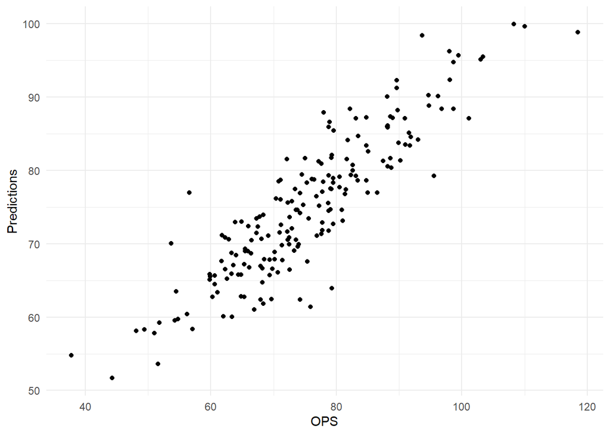

```r
# plot predicted vs observed
ggplot(test_mlb, aes(x = ops, y = .pred)) + geom_point() + theme_minimal() +
  labs(
    x = "OPS",
    y = "Predictions"
  )
```